# General Workflow Overview

This page outlines the general workflows I utilize for the analysis of sequencing data across various platforms. I generally follow these guidelines for most of my work and incorporate additional analyses based on the specific goals and discussions related to each project.

### List

1. scRNA-seq pipeline
2. RNA-seq pipeline
3. ChIP-seq/Cut&Run/ATAC-seq pipeline
4. Machine Learning application
5. Public DB

### scRNA-seq pipeline

- Fastq files QC: Fastqc, MultiQC
- 10X Genomics datasets (CellRanger) : count matrix
- Other formats: Drop-seq Tools, Salmon, STARsolo
- Demultiplexing (UMI-tools)
- Doublets-removal: scrublet, DoubletFinder
- Filtering by custom parameter
- Normalization and scaling : Seurat(SCTransform), log normalization
- Cell cycle phase : Seurat
- Integration and clustering : Seurat(CCA, Harmony), liger, Harmony
- Finding markers: Seurat, custom ML algorithm (XGBoost, Random Forest), DESeq2 and edgeR
- Visualization : Seurat functions, ggplot, plotly, shiny, heatmap, custom scripts
- Inter-cluster differential expression : MAST, DESeq2
- Imputation of gene expressions : MAGIC, scImpute
- Trajectories : Monocle3, destiny, slingshot
- pathway analysis: GSEA, scGSEA, clusterprofiler
- Network analysis: WGCNA, SCENIC
- Cell-Cell interaction : Cellchat
- RNA velocity : Velocyto
- scTCR/BCR-seq : VDJtools, immunarch, scRepertoire
- Tumor cell CNV : InferCNV

### RNA-seq pipeline

- Fastq files QC: Fastqc reports
- STAR,Salmon: countmatrix
- Normalization and scaling (if necessary)
- TPM, FPKM calculation
- PCA plots
- Correlation analysis of selected geneset
- DEG analysis
- GSEA
- Pathway analysis: GSEA, clusterprofiler
- K-means clustering of DEGs
- Visualization

### ChIP-seq/Cut&Run/ATAC-seq pipeline

- Fastq files QC: Fastqc reports
- Mapping: bowtie2
- Peak calling : macs2, SICER2
- bigwig file visualization : Deeptools, IGV, UCSC genome browser
- Custom analysis with bed files : BEDtools, GenomicRanges, rtracklayer, ChIPseeker
- Differentially Expressed Peaks : DESeq, edgeR
- TSS enrichment : Deeptools (computeMatrix)
- Motif discovery and analysis : HOMER, GREAT
- Tools for evaluating differential enrichment

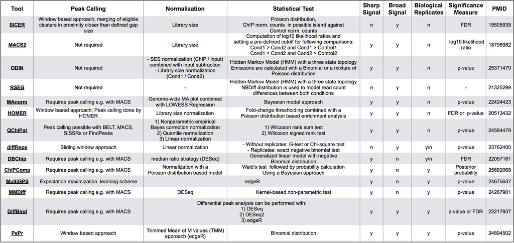

  https://hbctraining.github.io/Intro-to-ChIPseq/lessons/08_diffbind_differential_peaks.html

### Machine Learning application

#### Identification of variable features

- k-means clustering
- Elastic Net

#### Sampling data

- Bootstrap
- DBSCAN(Density-Based Spatial Clustering of Applications with Noise) sampling
- Random Forest based sampling

### Public DB

- TCGA
- CCLE
- GEO

### Frequently used Report formats

- Markdown(html)
- Rmarkdown(html)
- PPT slides(presentation)
- Excel dashboard
- Word format (for SOPs, method/guideline documents)
- Google Docs
- Github Pages(for open data/results)

### Useful links

Single-cell RNA-seq:  
[Integration: Seurat](https://hbctraining.github.io/scRNA-seq_online/lessons/06_integration.html)  
[Integration: Harmony](https://hbctraining.github.io/scRNA-seq_online/lessons/06a_integration_harmony.html)  
[Integration: Liger](https://cran.r-project.org/web/packages/rliger/vignettes/liger-vignette.html) [InferCNV](https://github.com/broadinstitute/inferCNV/wiki)

RNA-seq:  
[RNA-Seq Analysis in R using Rsubread](https://www.alzheimersworkbench.ucsd.edu/EndToEndAnalysis_RNASeq.html)

ChIP-seq:  
[Differential Peak calling using DiffBind](https://hbctraining.github.io/Intro-to-ChIPseq/lessons/08_diffbind_differential_peaks.html)